# Deskriptive Statistik

Maße der zentralen Tendenz und Streuung

Autor:in

Zugehörigkeit

Daniela Palleschi

Humboldt-Universität zu Berlin

Veröffentlichungsdatum

Mi. den 06.12.2023

Geändert

Mi. den 19.06.2024

# Lernziele

Heute werden wir lernen…

- über Maße der zentralen Tendenz (Mittelwert, Median, Modus)
- über Streuungsmaße (Bereich, Standardabweichung)
- wie man die Funktion `summarise()` von `dplyr` benutzt
- wie man Zusammenfassungen `.by` Gruppe erstellt

# 1 Lektüre

Die erforderliche Lektüre für dieses Thema sind:

1. Kap. 3, Abschnitte 3.4-3.9 (*Descriptive statistics, models, and distributions*) in Winter (2019) (online verfügbar für Studierende/Beschäftigte der HU Berlin über das [HU Grimm Zentrum](https://hu-berlin.hosted.exlibrisgroup.com/permalink/f/uig076/TN_cdi_askewsholts_vlebooks_9781351677431).
2. [Abschnitt 4.5 (Groups)](https://r4ds.hadley.nz/data-transform#groups) in Kap. 4 (*Data Transformation*) in Wickham et al. (2023).

# 2 Einrichten

# 3 Umgebung löschen

- Starten Sie ein neues Skript *immer* mit einer leeren R-Umgebung
  - keine Objekte in der Umgebung gespeichert
  - keine Pakete geladen
- Klicken Sie auf `Session > Restart R`, um mit einer neuen Umgebung zu beginnen
  - oder das Tastaturkürzel `Cmd/Ctrl+Strg+0`

## 3.1 Pakete

```r
pacman::p_load(tidyverse,
               here,
               janitor)
```

## 3.2 Daten laden

- zwei Datensätze heute:
  - `groesse_geburtstag_ws2324.csv`: ein leicht veränderter `groesse_geburtstag`-Datensatz von Winter Semester 2023/2024
  - `languageR_english.csv`: komprimierte Version des `english`-Datensatzes aus dem `languageR`-Paket
- wenn Sie diese Daten noch nicht haben, laden Sie sie von Moodle herunter

```r
df_groesse <- read_csv(here("daten", "groesse_geburtstag_ws2324.csv"))
```

```r
df_eng <- read_csv(here("daten", "languageR_english.csv")) |>
  clean_names() |>
  # fix some wonky variable names:
  rename(rt_lexdec = r_tlexdec,
         rt_naming = r_tnaming)
```

# 4 Deskriptive Statistik

- beschreibt quantitativ die zentrale Tendenz, Variabilität und Verteilung von Daten
  - auch zusammenfassende Statistik genannt
- z.B. Wertebereich (Minimum, Maximum), der Mittelwert und die Standardabweichung

## 4.1 Anzahl der Beobachtungen ($n$)

- ist keine Statistik, aber eine wichtige Information
  - mehr Daten (höher $n$) = mehr Beweise
  - weniger Daten (niedriger $n$) = möglicherweise nicht verallgemeinerbar auf die breitere Population
- `nrow()`: liefert die Anzahl der Beobachtungen in einem Datensatz

```r
nrow(df_groesse)
```

```
[1] 9
```

- `length()`: die Anzahl der Beobachtungen in einem Vektor oder einer Variablen

```r
length(df_groesse$groesse)
```

```
[1] 9
```

## 4.2 Maße der zentralen Tendenz (Lagemaße)

- beschreiben quantitativ die Mitte unserer Daten
  - der Mittelwert, der Median und der Modus

### 4.2.1 Mittelwert ($\mu$)

- der Mittelwert oder Durchschnitt: die Summe aller Werte geteilt durch die Anzahl der Werte (wie in Gleichung $\ref{eq-mean}$)

$$\begin{align}
\mu &= \frac{Summe\;der\;Werte}
{n} \label{eq-mean}
\end{align}$$

- können wir die Ergebnisse einer Gleichung als Objekt speichern
  - oder mehrere Werte als Vektor (eine Liste von Werten der gleichen Klasse)

```r
# save heights as a vector
heights <- c(171, 168, 182, 190, 170, 163, 164, 167, 189)
```

- könnten wir dann die Funktionen `sum()` und `length()` verwenden, um den Mittelwert zu berechnen

```r
# divide the sum of heights by the n of heights
sum(heights)/length(heights)
```

```
[1] 173.7778
```

- or simply use the `mean()` function.

```r
# or use the mean() function
mean(heights)
```

```
[1] 173.7778
```

- Wir können die Funktion `mean()` auch auf eine Variable in einem Datenrahmen anwenden, indem wir den Operator `$` verwenden (`datenrahmen$variable`).

```r
mean(df_groesse$groesse)
```

```
[1] 173.6667
```

### 4.2.2 Median

- der Wert in der Mitte des Datensatzes
- Wenn Sie Ihre Daten in der Reihenfolge ihrer Werte anordnen, liegt die Hälfte der Daten unter dem Median, die andere Hälfte darüber.

#### Median in R

- können wir die Funktion `sort()` verwenden und zählen, welches der mittlere Wert ist:

```r
sort(df_groesse$groesse)
```

```
[1] 163 164 167 167 170 171 182 189 190
```

- alternativ könnte man auch einfach die Funktion `median()` verwenden

```r
median(df_groesse$groesse)
```

```
[1] 170
```

### 4.2.3 Modus

- der Wert, der am häufigsten in einem Datensatz vorkommt
- keine R-Funktion zur Bestimmung des Modus
  - aber wir können ihn visualisieren, z.B. mit einem Histogramm oder einem Dichteplot

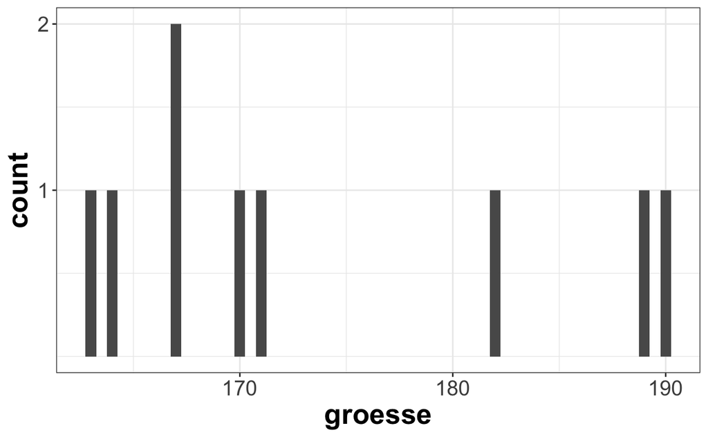

```r
df_groesse |>
  ggplot(aes(x = groesse)) +
  geom_histogram(binwidth = .5) +
  scale_y_continuous(breaks = c(1,2)) +
  theme_bw() +
  theme(axis.text = element_text(size = 15),
        axis.title = element_text(size = 20, face = "bold"))
```

## 4.3 Streuungsmaße

- beschreiben die Streuung von Datenpunkten
  - sagen uns etwas darüber, wie die Daten insgesamt verteilt sind

### 4.3.1 Bereich

- kann sich auf den höchsten (Maximum) und den niedrigsten (Minimum) Wert beziehen
  - oder die Differenz zwischen höchstem und niedrigstem Wert
- `max()` und `min()`: gibt den höchsten und den niedrigsten Wert aus

```r
max(heights)
```

```
[1] 190
```

```r
min(heights)
```

```
[1] 163
```

- oder die Funktion `range()` verwenden

```r
range(heights)
```

```
[1] 163 190
```

- Die Differenz zwischen diesen Werten erhält man, indem man den Minimalwert vom Maximalwert subtrahiert

```r
max(heights) - min(heights)
```

```
[1] 27
```

- In einem Histogramm oder Dichteplot: die niedrigsten und höchsten Werte auf der x-Achse

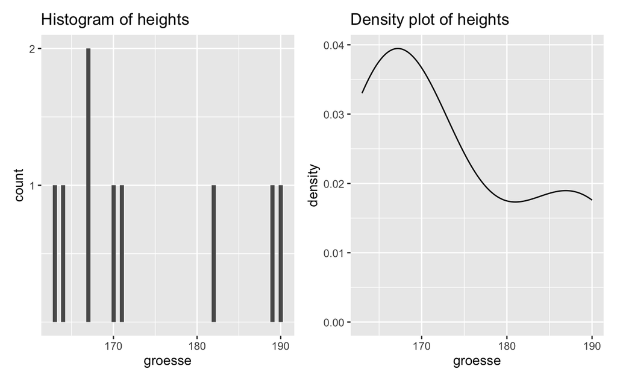

### 4.3.2 Standardabweichung (`sd` oder $\sigma$)

- ein Maß für die Streuung der Daten *im Verhältnis zum Mittelwert*
  - eine niedrige Standardabweichung bedeutet, dass die Daten um den Mittelwert herum gruppiert sind (d.h. es gibt eine geringere Streuung)
  - eine hohe Standardabweichung bedeutet, dass die Daten stärker gestreut sind
- Die Standardabweichung wird sehr oft angegeben, wenn der Mittelwert angegeben wird.
- Standardabweichung (`sd`) = die Quadratwurzel ($\sqrt{}$ oder `sqrt()` in R) der Summe der quadrierten Wertabweichungen vom Mittelwert ($(x - \mu)^2$) geteilt durch die Anzahl der Beobachtungen minus 1 ($n-1$)
  - gegeben in Gleichung $\ref{eq-sd}$

$$\begin{align}
\sigma & = \sqrt{\frac{(x_1-\mu)^2 + (x_2-\mu)^2 + ... + (x_N-\mu)^2}{N-1}} \label{eq-sd}
\end{align}$$

- das sieht einschüchternd aus, aber wir können die Standardabweichung in R mit der Funktion `sd()` berechnen

```r
sd(heights)
```

```
[1] 10.46157
```

- wir können die Standardabweichung von Hand berechnen, wenn wir wissen:
  - den Wert der einzelnen Beobachtungen
  - den Mittelwert dieser Werte
  - die Anzahl der Beobachtungen

$$\begin{align}
\sigma_{heights} & = \sqrt{\frac{(height_1-\mu)^2 + (height_2-\mu)^2 + ... (heights_N-\mu)^2}{N-1}}
\end{align}$$

```r
values <- c(3,5,16)
values
```

```
[1]  3  5 16
```

- Wenn wir diese zu Gleichung $\ref{eq-sd}$ hinzufügen, erhalten wir Gleichung $\ref{eq-sd1}$

$$\begin{align}
\sigma_{values} & = \sqrt{\frac{(3-\mu)^2 + (5-\mu)^2 + (16-\mu)^2}{N-1}} \label{eq-sd1}
\end{align}$$

- unser Mittelwert ($\mu$) ist:

```r
mean(values)
```

```
[1] 8
```

- Wenn wir diese zu Gleichung $\ref{eq-sd1}$ hinzufügen, erhalten wir Gleichung $\ref{eq-sd2}$.

$$\begin{align}
\sigma_{values} & = \sqrt{\frac{(3-8)^2 + (5-8)^2 + (16-8)^2}{N-1}} \label{eq-sd2}
\end{align}$$

- die Anzahl der Beobachtungen ($n$) ist:

```r
length(values)
```

```
[1] 3
```

- Wenn wir diese zu Gleichung $\ref{eq-sd2}$ hinzufügen, erhalten wir Gleichung $\ref{eq-sd3}$

$$\begin{align}
\sigma_{values} & = \sqrt{\frac{(3-8)^2 + (5-8)^2 + (16-8)^2}{3-1}} \label{eq-sd3}
\end{align}$$

- Wenn wir die restlichen Operationen durchführen, erhalten wir die Gleichungen $\ref{eq-sd4}$ bis $\ref{eq-sd}$:

$$\begin{align}
\sigma_{values} & = \sqrt{\frac{(-5)^2 + (-3)^2 + (8)^2}{3-1}} \\ \label{eq-sd4}
\\
& = \sqrt{\frac{25 + 9 + 64}{3-1}}
\\
& = \sqrt{\frac{98}{2}} \\
& = \sqrt{49} \\
& = 7
\end{align}$$

- unsere Arbeit überprüfen:

```r
sd(values)
```

```
[1] 7
```

# 5 Deskriptive Statistiken mit R

- das Paket `dplyr` aus dem `tidyverse` hat einige hilfreiche Funktionen, um zusammenfassende Statistiken zu erstellen
- Lassen Sie uns nun den `df_eng`-Datensatz verwenden, um diese `dplyr`-Verben kennenzulernen

## 5.1 `dplyr::summarise`

- Die Funktion `summarise()` (`dplyr`) berechnet Zusammenfassungen von Daten
  - aber wir müssen ihr sagen, *was* sie berechnen soll, und für welche Variable(n)
- die Funktion `n()` zum Beispiel liefert die Anzahl der Beobachtungen (nur wenn sie innerhalb von `summarise()` oder `mutate()` verwendet wird)

```r
df_eng |>
  summarise(N = n())
```

```
# A tibble: 1 × 1
      N
  <int>
1  4568
```

- wir können auch mehrere Berechnungen auf einmal durchführen
  - Ermitteln wir auch den Mittelwert und die Standardabweichung der lexikalischen Entscheidungsaufgabe (`rt_lexdec`, in Millisekunden)

```r
df_eng |>
  summarise(mean_lexdec = mean(rt_lexdec, na.rm=T),
            sd_lexdec = sd(rt_lexdec, na.rm = T),
            N = n())
```

```
# A tibble: 1 × 3
  mean_lexdec sd_lexdec     N
        <dbl>     <dbl> <int>
1        708.      115.  4568
```

**Fehlende Werte**

- Berechnungen sind bei fehlenden Werten nicht möglich
  - die Variable `rt_naming` hat einen fehlenden Wert
  - die Funktion `mean()` funktioniert nicht mit fehlenden Werten

```r
df_eng |>
  summarise(mean_naming = mean(rt_naming))
```

```
# A tibble: 1 × 1
  mean_naming
        <dbl>
1          NA
```

- können wir sie mit dem Verb `drop_na()` entfernen

```r
df_eng |>
  drop_na() |>
  summarise(mean_naming = mean(rt_naming))
```

```
# A tibble: 1 × 1
  mean_naming
        <dbl>
1        566.
```

# 6 Variablen gruppieren

## 6.1 `.by =`

- das Argument `.by =` in `summarise()` berechnet unsere Berechnungen für Gruppen innerhalb einer kategorialen Variable

```r
df_eng |>
  drop_na() |>
  summarise(mean_lexdec = mean(rt_lexdec),
            sd_lexdec = sd(rt_lexdec),
            N = n(),
            .by = age_subject) |>
  arrange(mean_lexdec)
```

```
# A tibble: 2 × 4
  age_subject mean_lexdec sd_lexdec     N
  <chr>             <dbl>     <dbl> <int>
1 young              630.      69.1  2283
2 old                787.      96.2  2284
```

## 6.2 Gruppieren nach mehreren Variablen

- wir können auch nach mehreren Variablen gruppieren
  - dafür brauchen wir `Verkettung` (`c()`)

```r
df_eng |>
  drop_na() |>
  summarise(mean_lexdec = mean(rt_lexdec),
            sd_lexdec = sd(rt_lexdec),
            N = n(),
            .by = c(age_subject, word_category)) |>
  arrange(age_subject)
```

```
# A tibble: 4 × 5
  age_subject word_category mean_lexdec sd_lexdec     N
  <chr>       <chr>               <dbl>     <dbl> <int>
1 old         N                    790.     101.   1452
2 old         V                    780.      86.5   832
3 young       N                    633.      70.8  1451
4 young       V                    623.      65.7   832
```

# 7 Das Quartett von Anscombe

- Francis Anscombe konstruierte 1973 4 Datensätze, um zu veranschaulichen, wie wichtig es ist, Daten zu visualisieren, bevor man sie analysiert und ein Modell erstellt
- Diese vier Diagramme stellen 4 Datensätze dar, die alle einen nahezu identischen Mittelwert und eine Standardabweichung, aber sehr unterschiedliche Verteilungen aufweisen

Tabelle 1: Summary stats of Anscombe’s quratet datasets

| dataset | mean_x | mean_y |
| --- | --- | --- |
| Dataset 1 | 9 | 7.5 |
| Dataset 2 | 9 | 7.5 |
| Dataset 3 | 9 | 7.5 |
| Dataset 4 | 9 | 7.5 |

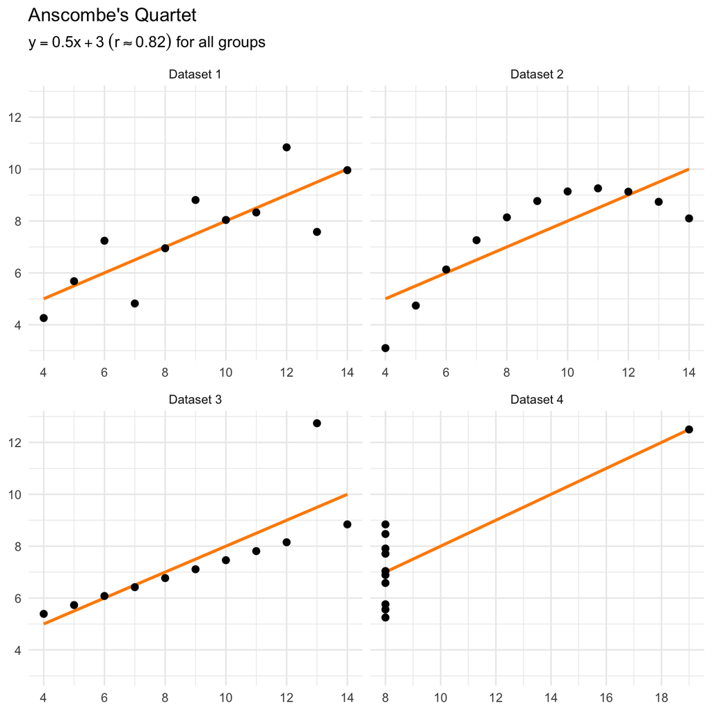

Abbildung 1: Plots of Anscombe’s quratet distributions

## 7.1 DatasaurRus

- datasauRus-Paket (Davies et al., 2022) enthält einige weitere Datensätze, die ähnliche Mittelwerte und Standardabweichung, aber unterschiedliche Verteilungen haben
  - angegeben in Tabelle 2

```r
pacman::p_load("datasauRus")
```

Tabelle 2: Zusammenfassende Statistiken der datasauRus-Datensätze

| dataset | mean_x | mean_y | std_dev_x | std_dev_y | corr_x_y |
| --- | --- | --- | --- | --- | --- |
| away | 54.27 | 47.83 | 16.77 | 26.94 | -0.06 |
| bullseye | 54.27 | 47.83 | 16.77 | 26.94 | -0.07 |
| circle | 54.27 | 47.84 | 16.76 | 26.93 | -0.07 |
| dino | 54.26 | 47.83 | 16.77 | 26.94 | -0.06 |
| dots | 54.26 | 47.84 | 16.77 | 26.93 | -0.06 |
| h_lines | 54.26 | 47.83 | 16.77 | 26.94 | -0.06 |
| high_lines | 54.27 | 47.84 | 16.77 | 26.94 | -0.07 |
| slant_down | 54.27 | 47.84 | 16.77 | 26.94 | -0.07 |
| slant_up | 54.27 | 47.83 | 16.77 | 26.94 | -0.07 |
| star | 54.27 | 47.84 | 16.77 | 26.93 | -0.06 |
| v_lines | 54.27 | 47.84 | 16.77 | 26.94 | -0.07 |
| wide_lines | 54.27 | 47.83 | 16.77 | 26.94 | -0.07 |
| x_shape | 54.26 | 47.84 | 16.77 | 26.93 | -0.07 |

- aber wenn wir sie aufzeichnen, sehen sie alle sehr unterschiedlich aus (Abbildung 2)!

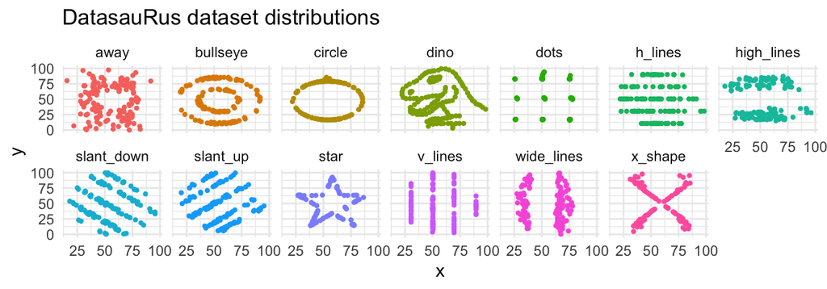

Abbildung 2: Plots of datasauRus dataset distributions

- Also, *immer die Daten aufzeichnen*
  - Schauen Sie sich nicht nur die deskriptiven Statistiken an!
- Beides ist sehr wichtig für das Verständnis Ihrer Daten.
- Nächste Woche sehen wir uns an, wie wir unsere zusammenfassenden Statistiken darstellen

# Learning objectives 🏁

Heute haben wir gelernt…

- über Maße der zentralen Tendenz ✅
- über Streuungsmaße ✅
- wie man die Funktion `summarise()` von `dplyr` benutzt ✅
- wie man Zusammenfassungen `.by` Gruppe erstellt ✅

# 8 Hausufgaben

[Anhang 7: Deskriptive Statistik](https://daniela-palleschi.github.io/r4ling/appendices/00-aufgaben.html#sec-app_desc_stats) auf der Website des Kurses.

# Session Info

Erstellt mit R version 4.4.0 (2024-04-24) (Puppy Cup) und RStudioversion 2023.9.0.463 (Desert Sunflower).

# Literaturverzeichnis

Davies, R., Locke, S., & D’Agostino McGowan, L. (2022). *datasauRus: Datasets from the Datasaurus Dozen*. https://CRAN.R-project.org/package=datasauRus

Wickham, H., Çetinkaya-Rundel, M., & Grolemund, G. (2023). *R for Data Science* (2. Aufl.).

Winter, B. (2019). Statistics for Linguists: An Introduction Using R. In *Statistics for Linguists: An Introduction Using R*. Routledge. https://doi.org/10.4324/9781315165547